# ANVIDEA - Reporte reproducible

Capítulo 4 — Modelos de crecimiento poblacional

Autor/a

Javier Rodríguez-Barrios

Fecha de publicación

18 de abril de 2026

# Presentación

Este reporte corresponde al **Capítulo 4 — Modelos de crecimiento poblacional** del proyecto **ANVIDEA**. Su propósito es ofrecer una versión operativa y reproducible de los contenidos del capítulo, conservando la lógica conceptual del libro y articulándola con scripts independientes que pueden ejecutarse localmente.

A diferencia de otros capítulos basados en bases de datos empíricas, aquí se trabaja principalmente con **simulación ecológica**.

**Lo que desarrolla este capítulo**

1. **Comprender el balance demográfico de las poblaciones**.
2. **Analizar el crecimiento bajo condiciones ideales** mediante el **modelo exponencial**.
3. **Incorporar la regulación ambiental** a través del **modelo logístico**.
4. **Interpretar la dinámica del crecimiento poblacional**.
5. **Explorar el efecto de los parámetros demográficos**.

# A. Modelo exponencial

## A.1 Modelo exponencial continuo

$$N(t) = N_0 \, e^{rt}$$

#### Ejemplo 1 — Curva con r positivo (fitoplancton)

$$T_d = \frac{\ln 2}{r} = \frac{0.6931}{0.4} \approx 1.73\;\text{horas}
\qquad
N(20) = 10\, e^{0.4 \cdot 20} \approx 2.98 \times 10^{4}\;\text{individuos}$$

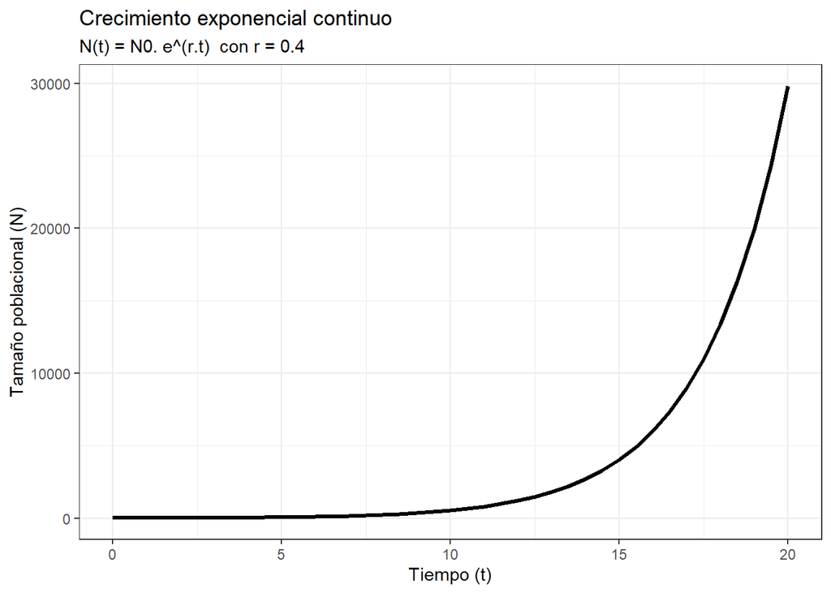

Figura 1: Crecimiento exponencial en tiempo continuo para la muestra de la población de fitoplancton.

#### Ejemplo 2 — r negativo: decrecimiento (peces)

$$T_{1/2} = \frac{\ln(1/2)}{r} = \frac{-0.6931}{-0.2} \approx 3.47\;\text{días}
\qquad
N(30) = 120\, e^{-0.2 \cdot 30} \approx 0.30\;\text{individuos}$$

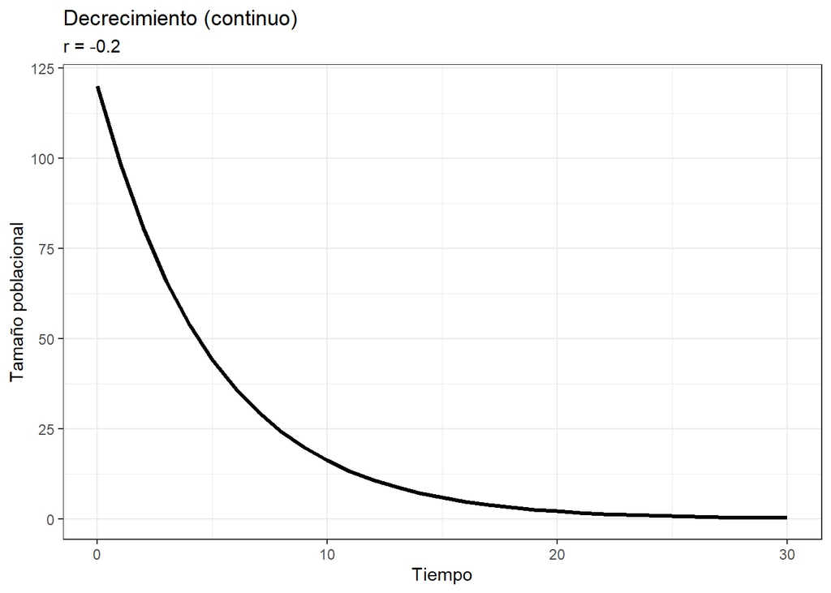

Figura 2: Patrón de reducción de la población de peces.

#### Ejemplo 3 — Comparación de múltiples r (insectos)

$$\begin{aligned}
r=0.1:&\quad N(20)=50\, e^{2} \approx 3.70\times10^{2}\\
r=0.3:&\quad N(20)=50\, e^{6} \approx 2.02\times10^{4}\\
r=0.5:&\quad N(20)=50\, e^{10}\approx 1.10\times10^{6}
\end{aligned}$$

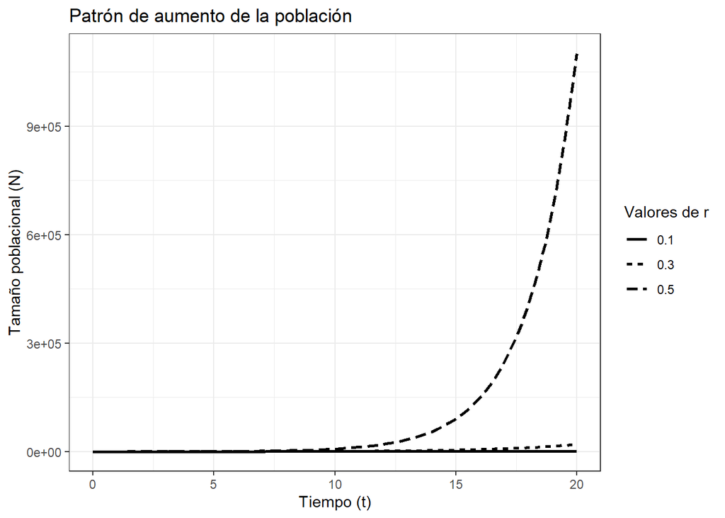

Figura 3: Patrón de crecimiento en poblaciones de insectos.

#### Ejemplo 4 — Tiempo de duplicación (Td) y semirreducción (T½)

Tabla 1: Visualización de Td con r>0 y T½ con r<0 en función de r.

| r | Metrica | Tiempo |
| --- | --- | --- |
| -0.50 | Tsr | 1.39 |
| -0.25 | Tsr | 2.77 |
| -0.10 | Tsr | 6.93 |
| 0.10 | Td | 6.93 |
| 0.25 | Td | 2.77 |
| 0.50 | Td | 1.39 |

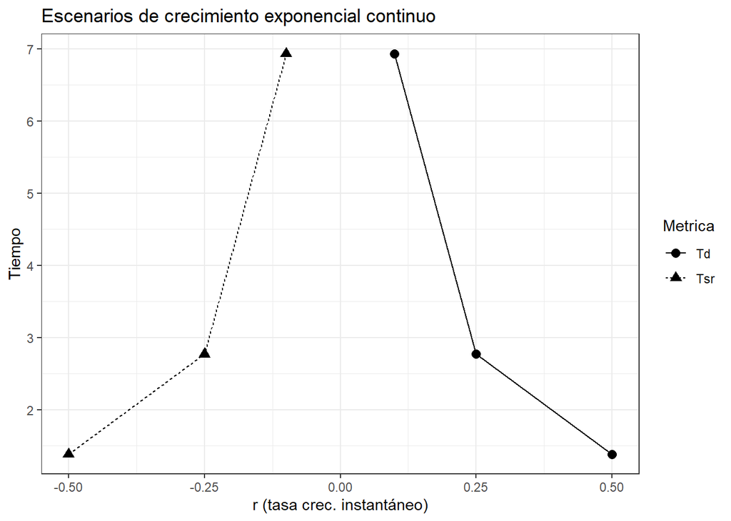

Figura 4: Visualización de Td con r>0 y T½ con r<0 en función del crecimiento instantáneo r.

#### Ejemplo 5 — Velocidad instantánea dN/dt = rN (invertebrados)

$$\frac{dN}{dt} = rN = 0.2 \times 30 = 6\;\text{individuos/día}
\qquad
N(25) = 30\, e^{0.2 \cdot 25} \approx 4.45 \times 10^{3}\;\text{invertebrados}$$

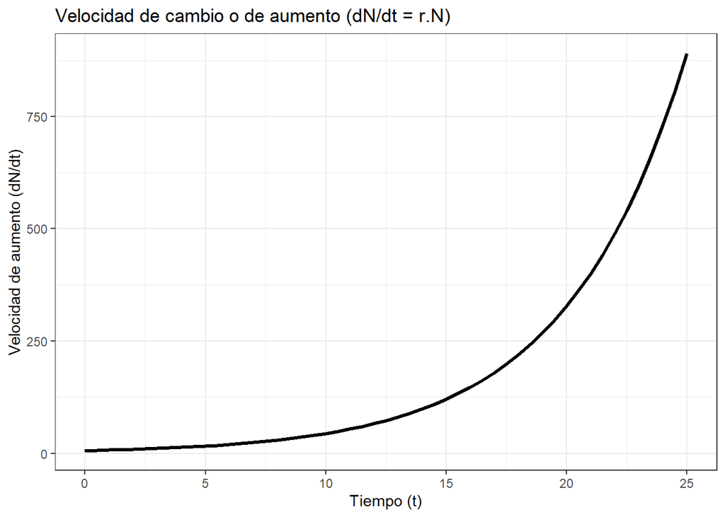

Figura 5: Patrón de crecimiento exponencial para la población de invertebrados.

#### Ejemplo 6 — Estimar r con dos observaciones

Tabla 2: Estimación de r a partir de valores (N0, Nt, t).

| N0 | Nt | t | r |
| --- | --- | --- | --- |
| 40 | 120 | 10 | 0.11 |
| 80 | 20 | 8 | -0.17 |
| 50 | 50 | 12 | 0.00 |
| 30 | 200 | 15 | 0.13 |

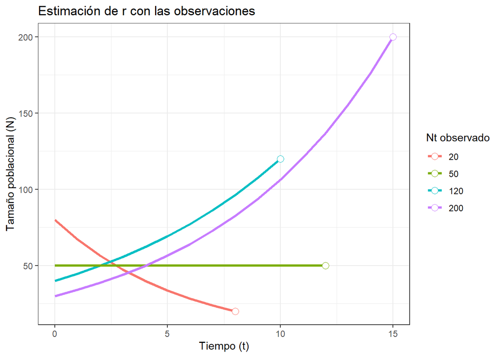

Figura 6: Trayectorias poblacionales estimadas a partir de r calculado con cuatro escenarios.

#### Ejemplo 7 — Estimar r en una población bacteriana

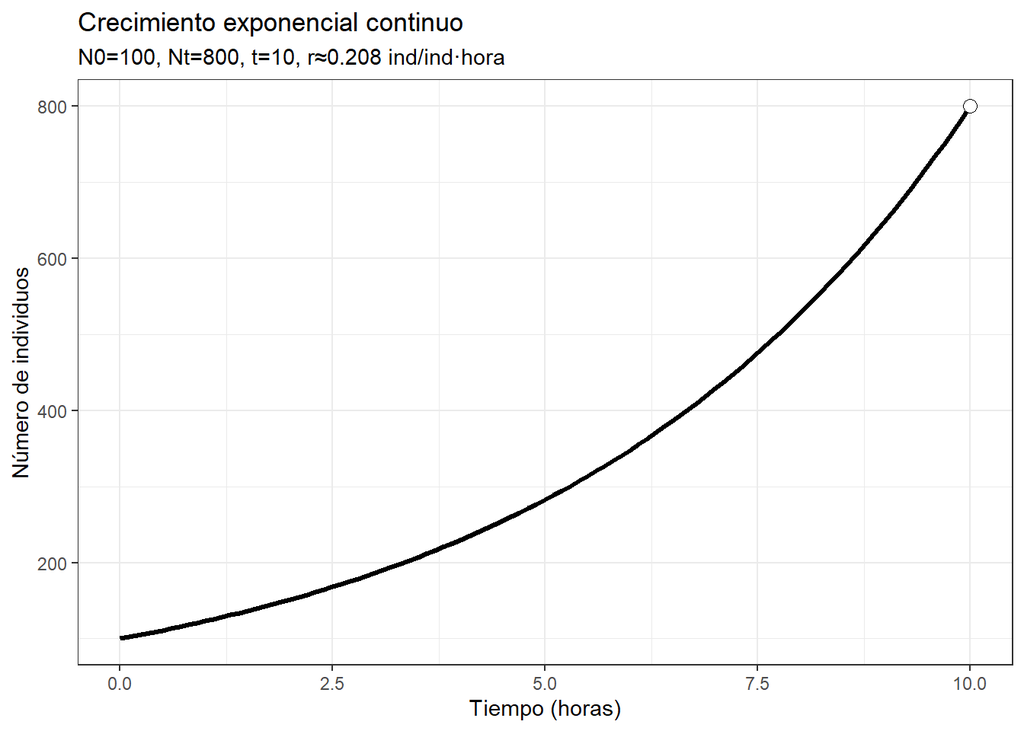

Figura 7: Crecimiento continuo estimado en bacterias.

## A.2 Modelo exponencial discreto

$$N_t = N_0 \, \lambda^t$$

#### Ejemplo 1 — λ > 1: crecimiento (plantas)

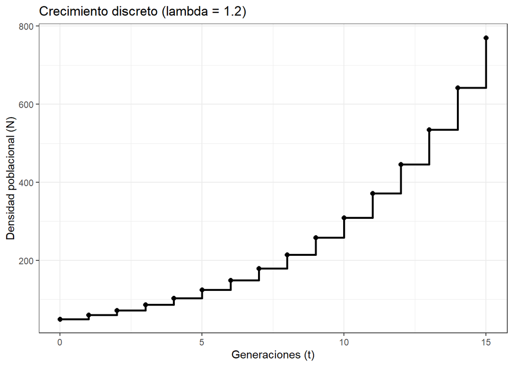

Figura 8: Proyección de crecimiento exponencial discreto.

#### Ejemplo 2 — λ = 1: población estable

$$N(t) = 100 \cdot 1^t = 100 \quad \text{para cualquier } t$$

| t | N |
| --- | --- |
| 0 | 100 |
| 1 | 100 |
| 2 | 100 |
| 3 | 100 |
| 4 | 100 |
| 5 | 100 |
| 6 | 100 |
| 7 | 100 |
| 8 | 100 |
| 9 | 100 |
| 10 | 100 |

#### Ejemplo 3 — λ < 1: decrecimiento (aves migratorias)

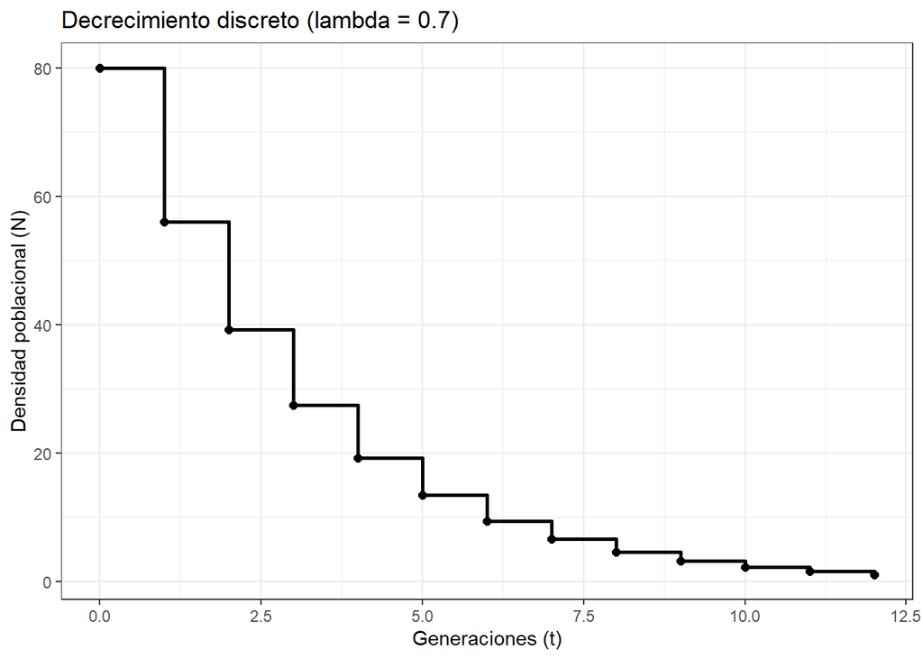

Figura 9: Patrón de disminución o decrecimiento de las aves migratorias.

#### Ejemplo 4 — Comparación: continuo vs. discreto

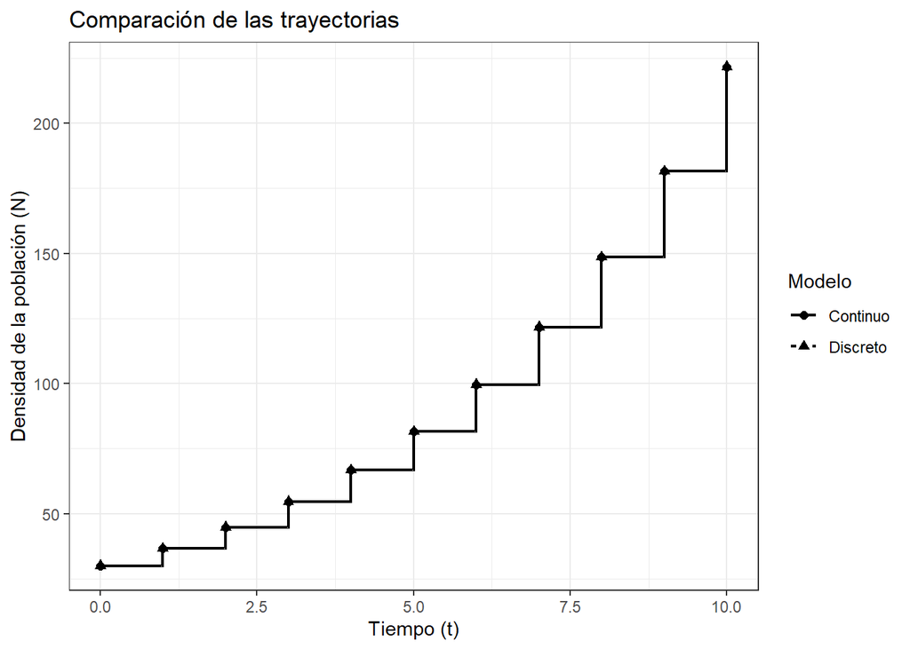

Figura 10: Comparación de trayectorias continua y discreta con r = 0.2.

#### Ejemplo 5 — Estimar λ a partir de escenarios

$$\lambda = \left(\frac{N_t}{N_0}\right)^{1/t}$$

Tabla 3: Estimación de lambda a partir de (N0, Nt, t) en un conjunto de escenarios.

| No | Nt | t | Lambda | Interpretacion |
| --- | --- | --- | --- | --- |
| 60 | 240 | 6 | 1.26 | Crecimiento (λ>1) |
| 100 | 100 | 10 | 1.00 | Estable (λ=1) |
| 80 | 20 | 8 | 0.84 | Decrecimiento (λ<1) |
| 30 | 300 | 10 | 1.26 | Crecimiento (λ>1) |

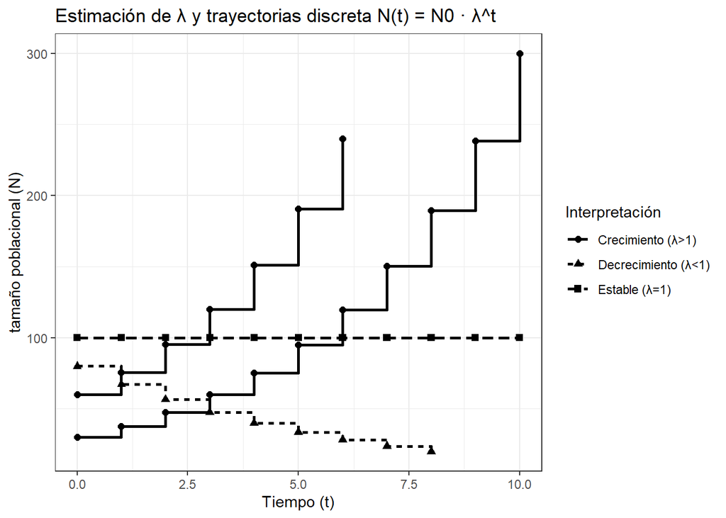

Figura 11: Trayectorias discretas estimadas con lambda calculado a partir de dos observaciones.

#### Ejemplo 6 — Reconstruir r a partir de λ

$$r = \ln(\lambda)$$

Tabla 4: Conversión de λ a r y métricas derivadas.

| lambda | r | clasificacion | T_dup | T_half |
| --- | --- | --- | --- | --- |
| 0.6 | -0.51 | Decrecimiento | NA | 1.36 |
| 0.8 | -0.22 | Decrecimiento | NA | 3.11 |
| 1.0 | 0.00 | Estable | NA | NA |
| 1.2 | 0.18 | Crecimiento | 3.80 | NA |
| 1.5 | 0.41 | Crecimiento | 1.71 | NA |

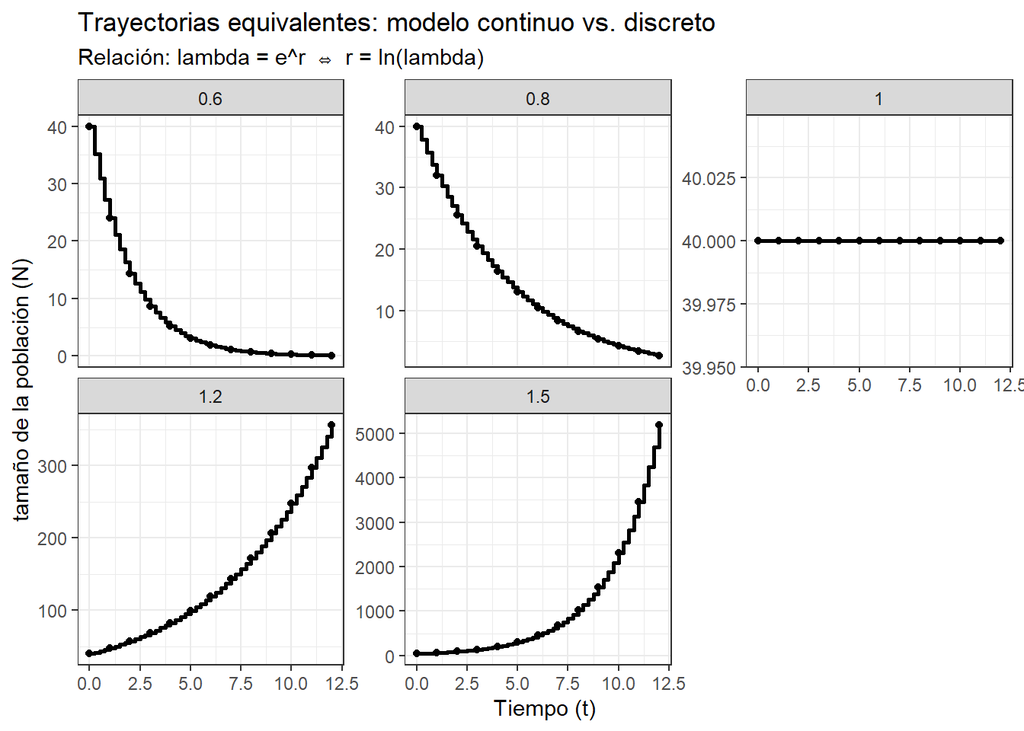

Figura 12: Comparación de trayectorias: continuo (r = ln λ) vs. discreto (λ) para varios valores de λ.

# B. Modelo logístico

$$\frac{dN}{dt} = rN\left(1-\frac{N}{K}\right)
\qquad
N(t) = \frac{K}{1 + \left(\frac{K-N_0}{N_0}\right)e^{-rt}}$$

#### Ejemplo 1 — Tasa inicial dN/dt

$$\left.\frac{dN}{dt}\right|_{t=0} = rN_0\left(1 - \frac{N_0}{K}\right)
= 0.05 \times 500 \times \left(1 - \frac{500}{10000}\right) = 23.75$$

```r
r <- 0.05; N0 <- 500; K <- 10000
dNdt_0 <- r * N0 * (1 - N0 / K)
dNdt_0
```

```
[1] 23.75
```

```r
# Segundo escenario
r <- 0.04; N0 <- 200; K <- 5000
r * N0 * (1 - N0 / K)
```

```
[1] 7.68
```

#### Ejemplo 2 — Tamaño tras 6 meses (t = 180 días)

```r
N0 <- 100; K <- 400; r <- 0.02; t <- 180
N_t <- K / (1 + ((K - N0) / N0) * exp(-r * t))
N_t
```

```
[1] 369.6956
```

```r
# Tiempo requerido para alcanzar 80% de K
N0 <- 50; K <- 500; r <- 0.1; Nstar <- 0.8 * K
t_req <- (1 / r) * log(((K - N0) / N0) * (Nstar / (K - Nstar)))
t_req
```

```
[1] 35.83519
```

#### Ejemplo 3 — Curva logística base (simulación)

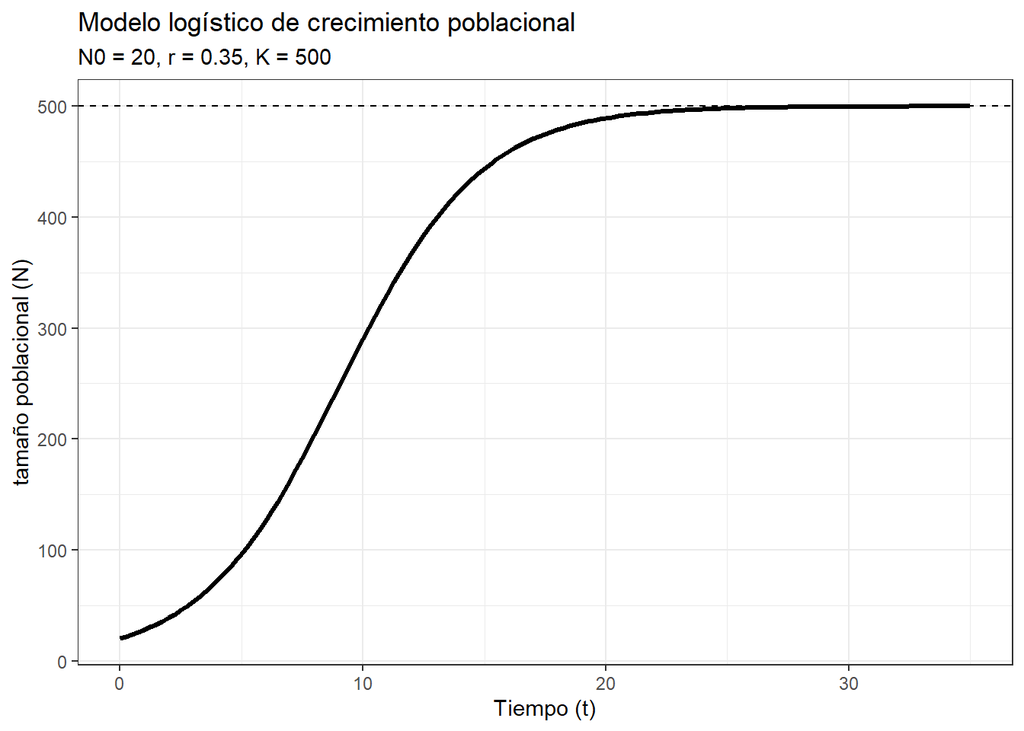

Figura 13: Modelo logístico de crecimiento poblacional (N0 = 20, r = 0.35, K = 500).

#### Ejemplo 4 — b’(N) cuadrática y d’(N) lineal

Valores de b’ y d’ en función de N (cada 5 unidades).

| N | b' | d' |
| --- | --- | --- |
| 0 | 0.12 | 0.18 |
| 5 | 0.17 | 0.22 |
| 10 | 0.21 | 0.26 |
| 15 | 0.25 | 0.30 |
| 20 | 0.28 | 0.34 |
| 25 | 0.31 | 0.38 |
| 30 | 0.33 | 0.42 |
| 35 | 0.35 | 0.46 |
| 40 | 0.36 | 0.50 |
| 45 | 0.37 | 0.54 |
| 50 | 0.37 | 0.58 |

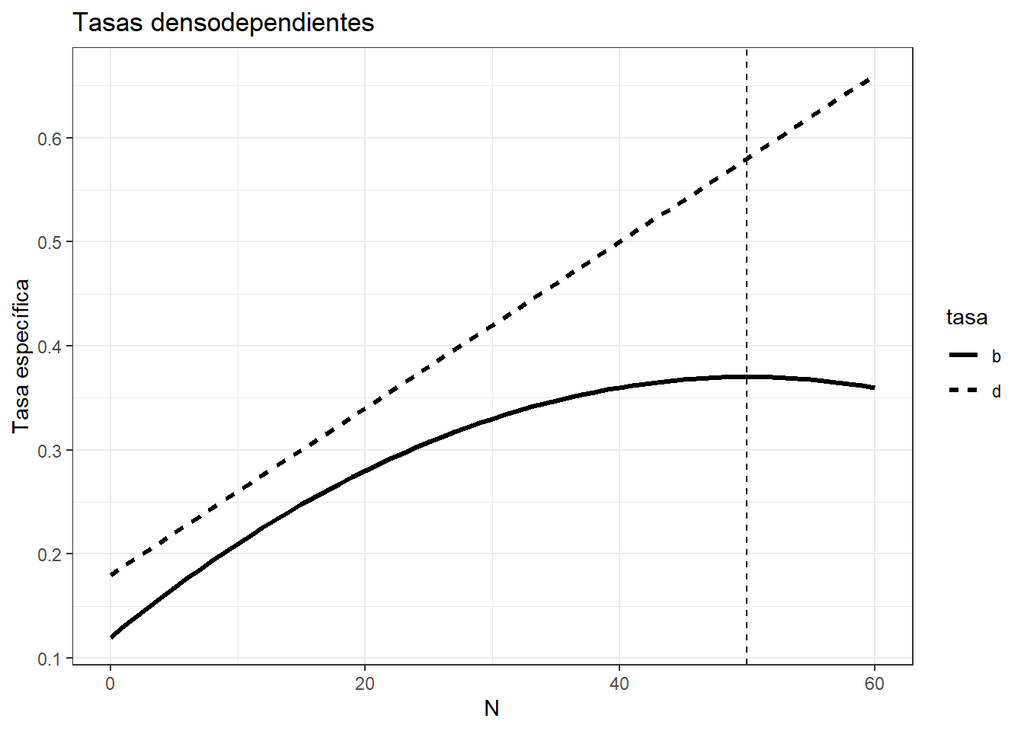

Figura 14: b’(N) (cuadrática) y d’(N) (lineal). El máximo de b’ ocurre en N = 50.

#### Ejemplo 5 — Población tras 12 meses

```r
N0 <- 150; K <- 3000; r <- 0.03; t <- 12
K / (1 + ((K - N0) / N0) * exp(-r * t))
```

```
[1] 210.4399
```

#### Ejemplo 6 — Tiempo hasta 75% de K

```r
N0 <- 50; K <- 800; r <- 0.08; Nstar <- 0.75 * K
(1 / r) * log(((K - N0) / N0) * (Nstar / (K - Nstar)))
```

```
[1] 47.58328
```

#### Ejemplo 7 — K reducida por degradación

```r
N0 <- 200; Kp <- 840; r <- 0.06; f <- 0.99; Nstar <- f * Kp
t_99 <- (1 / r) * log(((Kp - N0) / N0) * (Nstar / (Kp - Nstar)))
t_99
```

```
[1] 95.97118
```

#### Ejemplo 8 — Tamaño tras 24 h

```r
r <- 0.07; K <- 50000; N0 <- 1000; t <- 24
K / (1 + ((K - N0) / N0) * exp(-r * t))
```

```
[1] 4934.702
```

#### Ejemplo 9 — Equilibrio con b’(N) y d’(N): detección numérica

```r
b2   <- function(N) 0.10 + 0.015 * N - 0.00015 * N^2
d2   <- function(N) 0.12 + 0.006  * N
f_eq <- function(N) b2(N) - d2(N)

uniroot_all <- function(f, interval, n = 2000) {
  xs          <- seq(interval[1], interval[2], length.out = n)
  ys          <- f(xs)
  sign_change <- which(diff(sign(ys)) != 0)
  roots       <- purrr::map_dbl(sign_change,
                                 ~ uniroot(f, c(xs[.x], xs[.x + 1]))$root)
  unique(round(roots, 6))
}

roots <- uniroot_all(f_eq, c(0, 1000))
roots
```

```
[1]  2.311254 57.688746
```

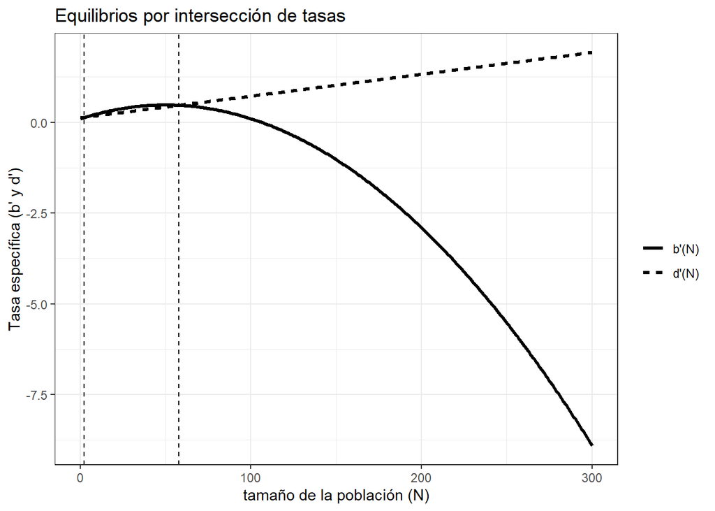

Figura 15: Intersección b’(N) = d’(N) define los estados de equilibrio.

#### Ejemplo 10 — Tiempo para duplicar N0

```r
r <- 0.05; K <- 1000; N0 <- 200; Nstar <- 2 * N0
(1 / r) * log(((K - N0) / N0) * (Nstar / (K - Nstar)))
```

```
[1] 19.61659
```

#### Ejemplo 11 — Tasa dN/dt en t = 10 días

```r
r <- 0.09; K <- 10000; N0 <- 500; t <- 10
N10     <- K / (1 + ((K - N0) / N0) * exp(-r * t))
dNdt_10 <- r * N10 * (1 - N10 / K)
N10; dNdt_10
```

```
[1] 1146.155
```

```
[1] 91.33091
```

## B.2 Simulaciones — Efecto de los parámetros

#### Efecto de la capacidad de carga (K)

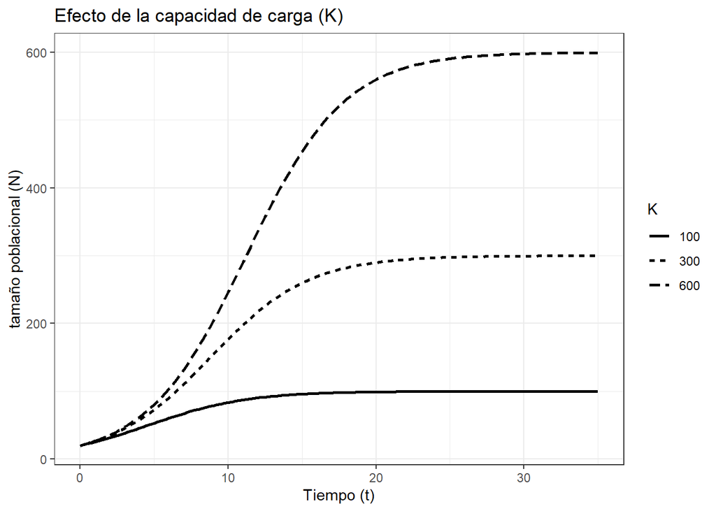

Figura 16: Efecto de distintos valores de K sobre la trayectoria logística.

#### Efecto de la tasa intrínseca de crecimiento (r)

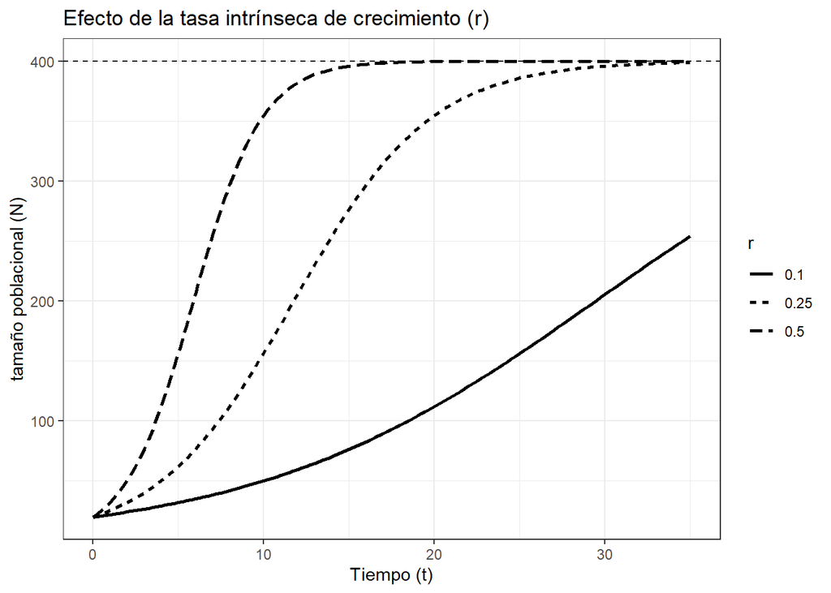

Figura 17: Efecto de distintos valores de r sobre la trayectoria logística (K = 400).

#### Velocidad de crecimiento dN/dt = rN(1 - N/K)

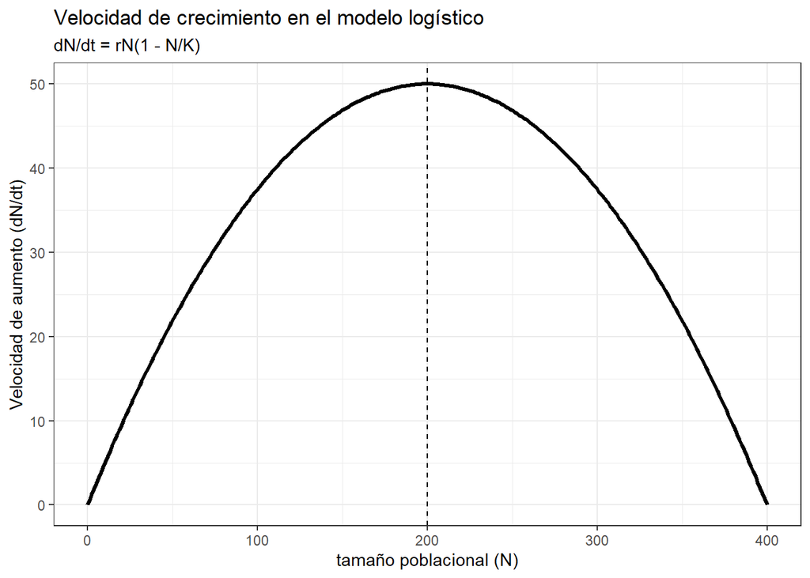

Figura 18: Velocidad de crecimiento parabólica del modelo logístico. El máximo ocurre en N = K/2.

#### Comparación: exponencial vs. logístico

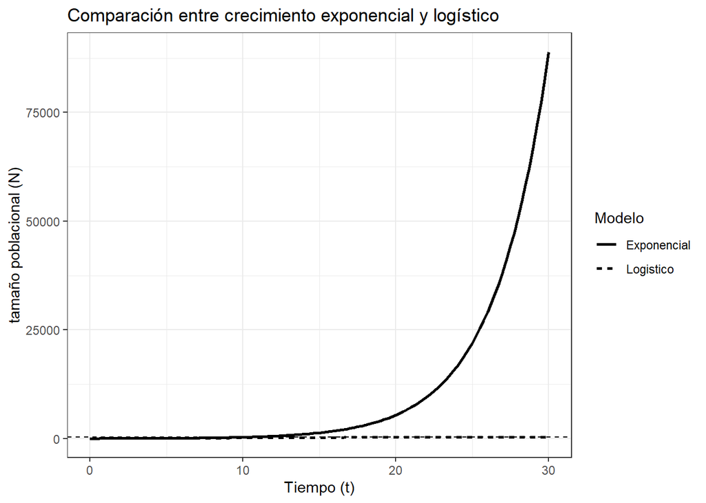

Figura 19: Comparación entre crecimiento exponencial y logístico (N0 = 20, r = 0.28, K = 300).

#### Influencia del tamaño inicial (N0)

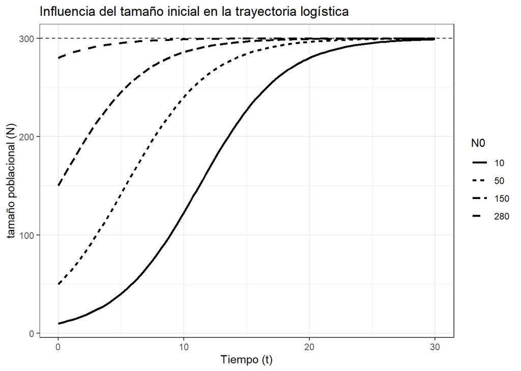

Figura 20: Influencia del tamaño inicial N0 sobre la trayectoria logística (r = 0.30, K = 300).

## B.3 Tabla resumen comparativa

Tabla 5: Comparación entre el modelo exponencial y el modelo logístico.

| Aspecto | Modelo exponencial | Modelo logístico |
| --- | --- | --- |
| Supuesto central | No hay limitación ambiental | Existe limitación por recursos |
| Parámetro clave | r o λ | r y K |
| Forma de la curva | J | Sigmoide |
| Regulación densidad | No | Sí |
| Aplicación conceptual | Potencial biótico | Crecimiento regulado |

# Errores comunes e interpretación ecológica

Un error frecuente consiste en asumir que el crecimiento exponencial describe permanentemente a las poblaciones naturales. En realidad, suele representar fases tempranas o condiciones excepcionales (poblaciones invasoras, cultivos bacterianos, primeras etapas de recolonización).

También es común interpretar $K$ como un valor fijo e inmutable. En ecosistemas reales, $K$ varía con el tiempo en función de la disponibilidad de recursos, la calidad del hábitat y las perturbaciones ambientales.

Finalmente, conviene recordar que $r$ y $\lambda$ no son parámetros independientes: $\lambda = e^r$. Confundirlos conduce a errores de escala en las proyecciones poblacionales.

# Transición hacia el siguiente capítulo

Hasta aquí el análisis se ha centrado en el **tamaño total de la población** como variable de estado, asumiendo que todos los individuos son demográficamente equivalentes. El siguiente capítulo abordará la **estructura interna de las poblaciones** mediante tablas de vida y modelos matriciales, incorporando la edad o estadio de los individuos como dimensión analítica fundamental.